# Rejection Sampling

Amy Chen

October 16, 2018

### Overview

Rejection sampling is a method of drawing points from a target distribution by sampling from an easier distribution and correcting the sampling probability through the rejection of some candidates.  
Suppose we are interested in drawing points from $f(x)$. Let $g$ denote another density from which we know how to sample and for which we can easily calculate $g(x)$. Let $e$ denote an envelope such that $e(x) = \frac{g(x)}{\alpha}\geq f(x) \forall x$ for which $f(x) > 0$ for a given constant $\alpha \leq 1$.  
Then rejection sampling can be completed in the following steps:

1. Sample $Y$ ~ $g$
2. Sample $U$ ~ $Unif(0,1)$
3. Reject $Y$ if $U > \frac{f(Y)}{e(Y)}$, otherwise keep $Y$
4. Repeat for desired sample size

### Demonstration

**Suppose we would like to estimate $S= E[x^2]$ where $X$ has density proportional to $q(x) = e^ \frac{-|x|^3}{3}\$**

#### Target Function

Let the target function be $f(x) = e^ \frac{-|x|^3}{3}\$

#### Envelope Function

Consider using the standard normal distribution $N(0,1)$

$g = \frac{1}{\sqrt{2\pi}}e^{\frac{-x^2}{2}}$

To determine $e$, we must find $\alpha$ such that $\frac{g(x)}{\alpha} > f(x)$. Choose $\alpha = 0.3$.

```r
f <- function(x) {
  exp(-abs(x^3)/3)
}
e <- function(x) {
  dnorm(x)/0.3
}
```

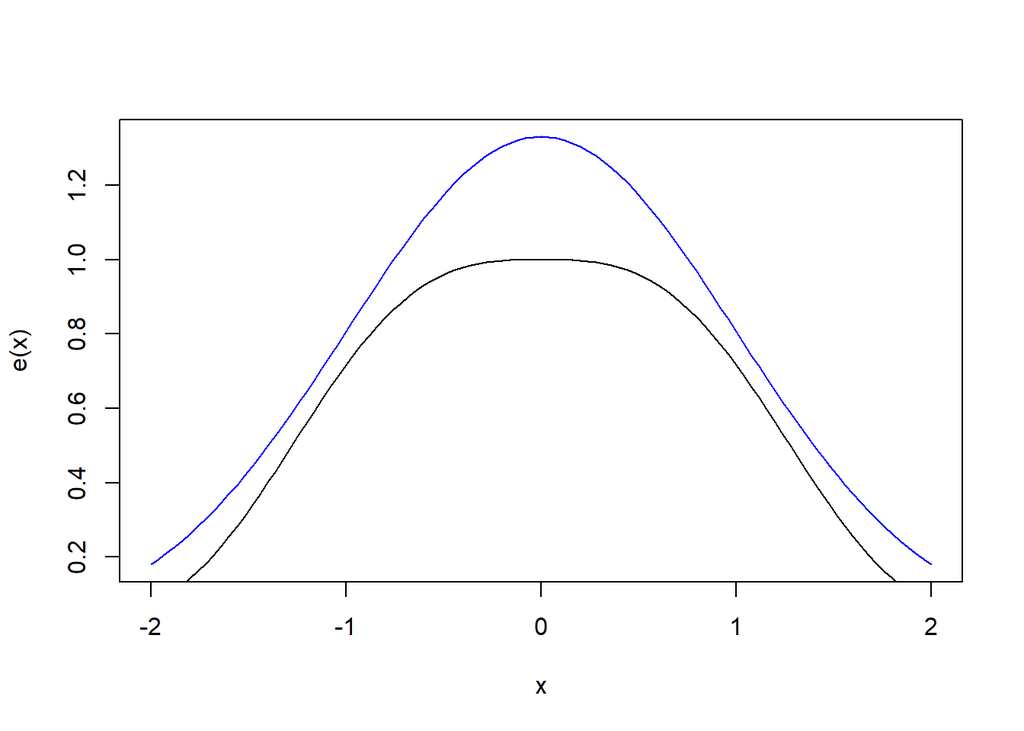

```r
curve(e(x), from = -2, to = 2, col = "blue")
curve(f(x), add = T)
```

#### Rejection Sampling

Follow the steps listed above for a sample size of 100,000. Below are a few points drawn using this method.

```r
n = 100000
y = rnorm(n, 0, 1)
u = runif(n)
x = y[u < f(y)/e(y)]
head(x)
```

```
## [1]  1.14850878 -0.16326236 -0.17638245  0.04891202  0.05516292  0.65279403
```

The acceptance ratio is

```r
length(x)/n
```

```
## [1] 0.7733
```

#### Calculate $E[x^2]$

Now that we have our points from the sample, square each accepted x, and take the mean to get $E[x^2]$.

```r
mean(x^2)
```

```
## [1] 0.7801127
```